# CMPINF 2130 Summer 2021 - Week 02

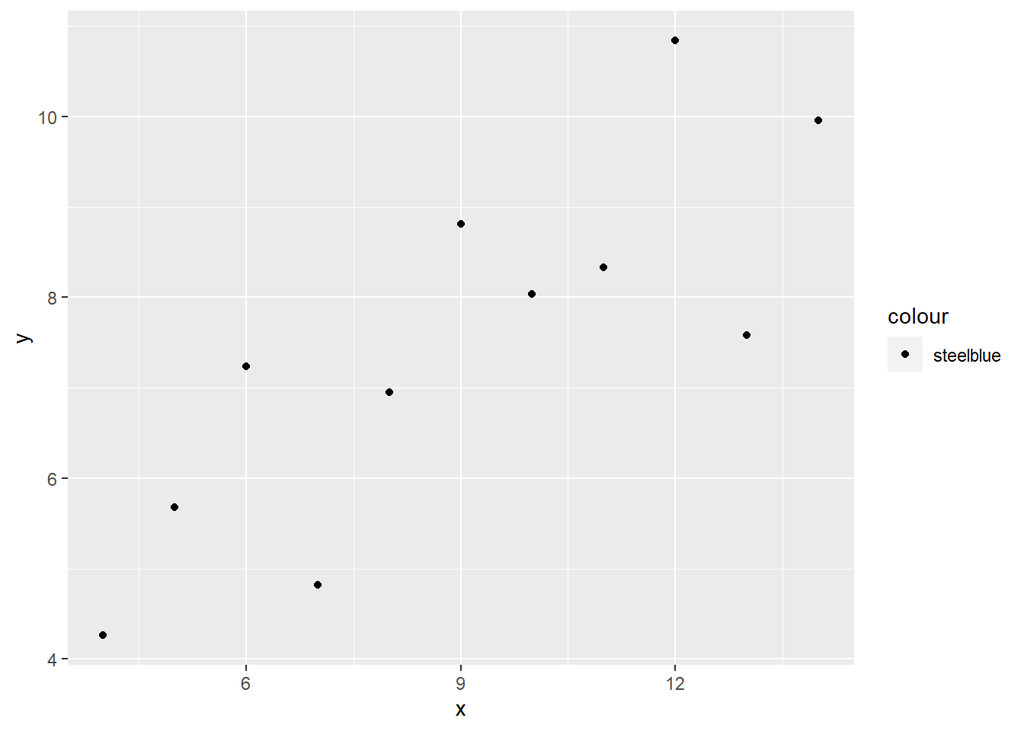

```r
a1 %>%
  ggplot(mapping = aes(x = x, y = y)) +
  geom_point(mapping = aes(color = 'steelblue')) +
  ggthemes::scale_color_colorblind()
```

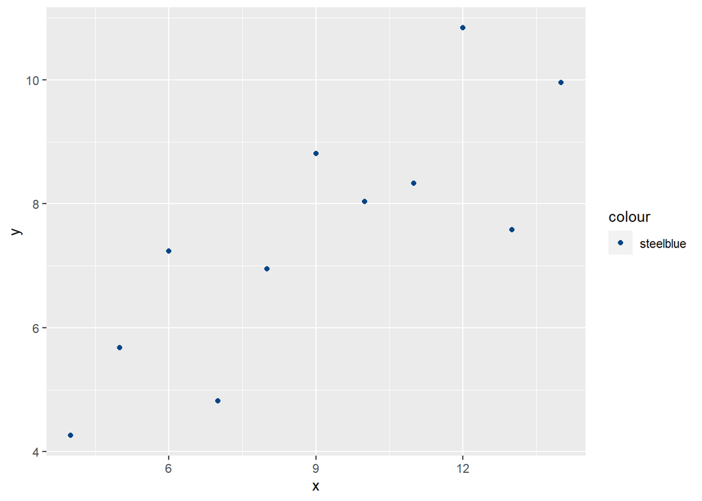

```r
a1 %>%
  ggplot(mapping = aes(x = x, y = y)) +
  geom_point(mapping = aes(color = 'steelblue')) +
  ggthemes::scale_color_calc()
```

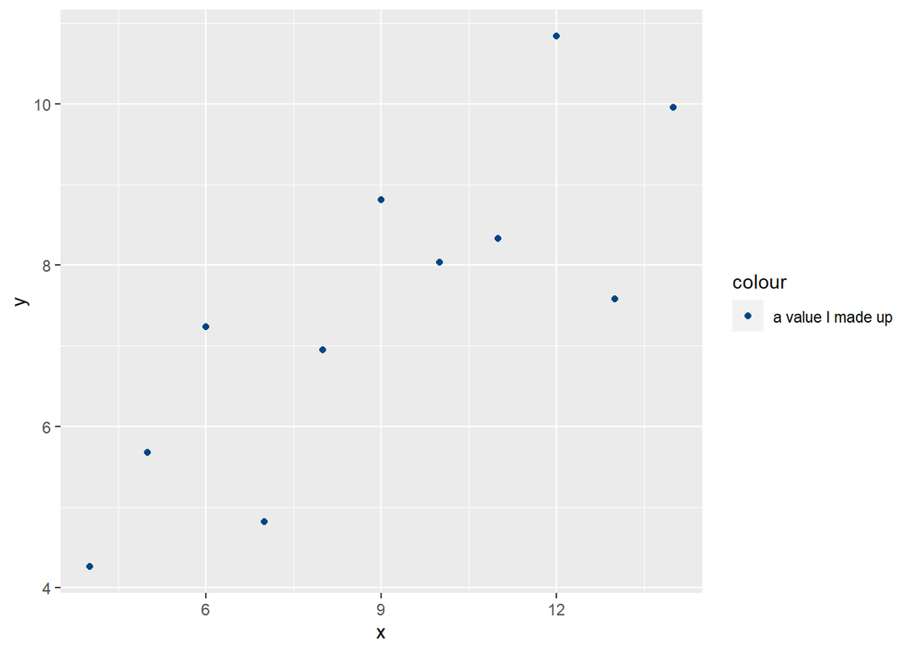

```r
a1 %>%
  ggplot(mapping = aes(x = x, y = y)) +
  geom_point(mapping = aes(color = 'a value I made up')) +
  ggthemes::scale_color_calc()
```

`ggplot()` thinks there’s a variable with a value `steelblue` and the legend exists to reference the possible values represented by the color.

If we want to “hard code” a visual quality a visual aesthetic we place that assignment **outside** the `aes()` function.

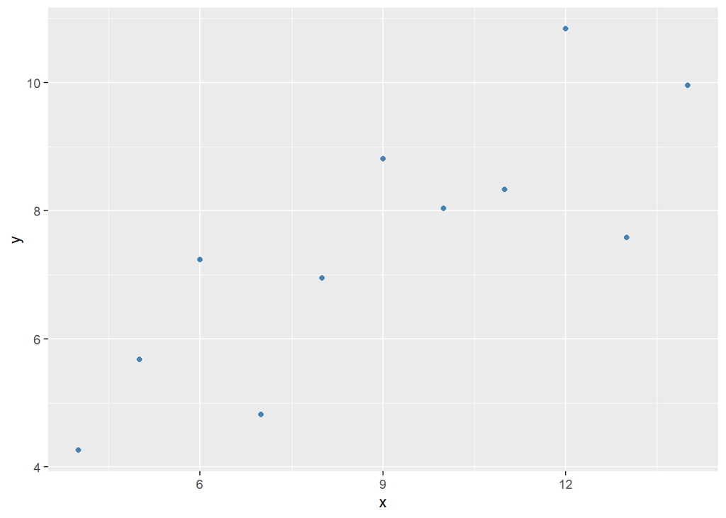

```r
a1 %>%
  ggplot(mapping = aes(x = x, y = y)) +
  geom_point(color = 'steelblue')
```

Let’s change the marker size.

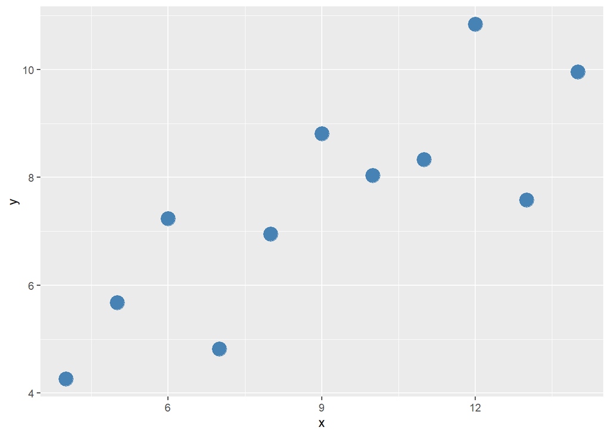

```r
a1 %>%
  ggplot(mapping = aes(x = x, y = y)) +
  geom_point(color = 'steelblue', size = 5.5)
```

Change the marker shape with the `shape` argument.

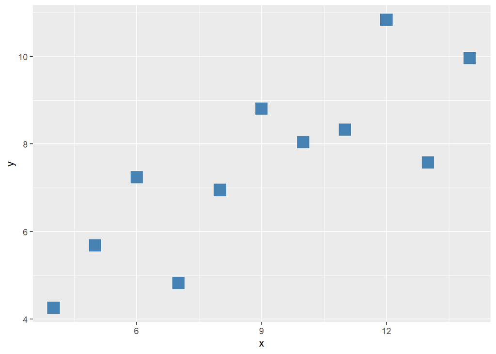

```r
a1 %>%
  ggplot(mapping = aes(x = x, y = y)) +
  geom_point(color = 'steelblue', size = 5.5, shape = 15)
```

## Iris

```r
iris %>% glimpse()
```

```
## Rows: 150
## Columns: 5
## $ Sepal.Length <dbl> 5.1, 4.9, 4.7, 4.6, 5.0, 5.4, 4.6, 5.0, 4.4, 4.9, 5.4, 4.~
## $ Sepal.Width  <dbl> 3.5, 3.0, 3.2, 3.1, 3.6, 3.9, 3.4, 3.4, 2.9, 3.1, 3.7, 3.~
## $ Petal.Length <dbl> 1.4, 1.4, 1.3, 1.5, 1.4, 1.7, 1.4, 1.5, 1.4, 1.5, 1.5, 1.~
## $ Petal.Width  <dbl> 0.2, 0.2, 0.2, 0.2, 0.2, 0.4, 0.3, 0.2, 0.2, 0.1, 0.2, 0.~
## $ Species      <fct> setosa, setosa, setosa, setosa, setosa, setosa, setosa, s~
```

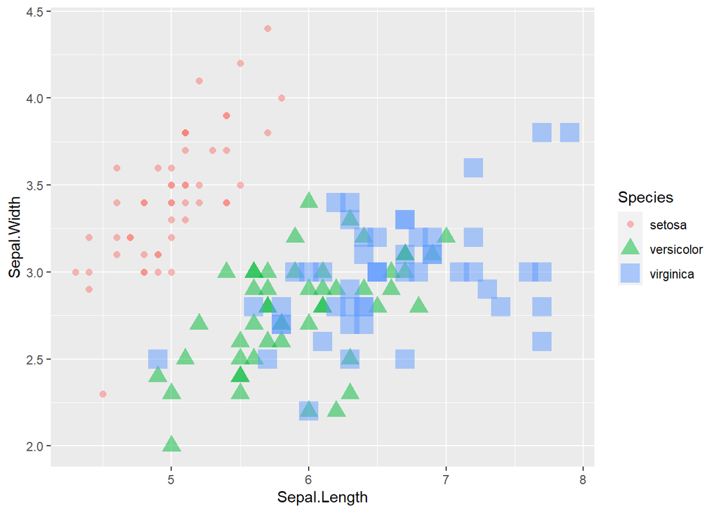

```r
iris %>%
  ggplot(mapping = aes(x = Sepal.Length, y = Sepal.Width)) +
  geom_point(mapping = aes(color = Species,
                           shape = Species,
                           size = Species),
             alpha = 0.5)
```

Let’s use a manual size scale for the Species.

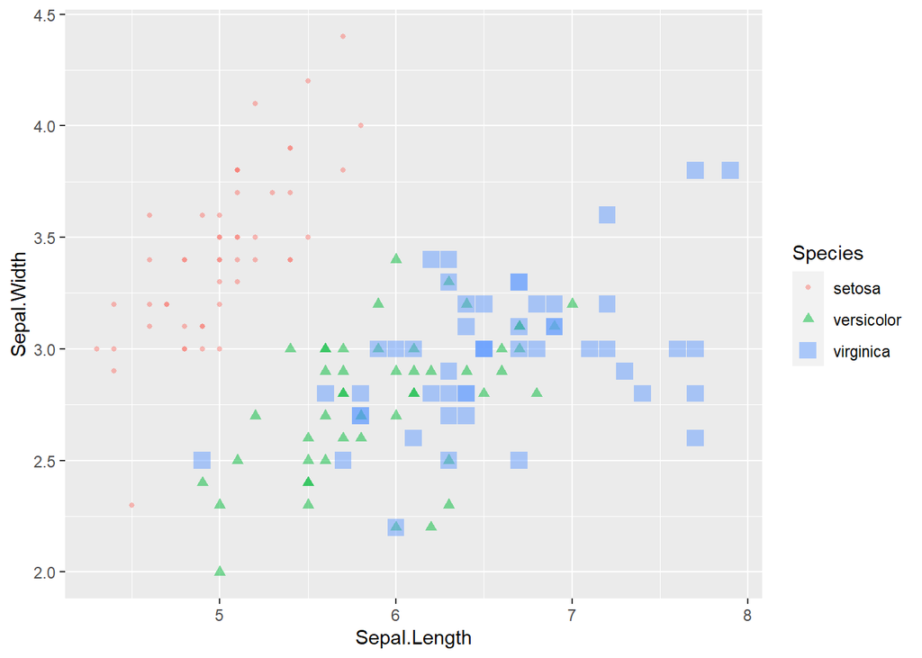

```r
my_size_values <- c(1, 2, 4)

names(my_size_values) <- iris %>% distinct(Species) %>% pull()

iris %>%
  ggplot(mapping = aes(x = Sepal.Length, y = Sepal.Width)) +
  geom_point(mapping = aes(color = Species,
                           shape = Species,
                           size = Species),
             alpha = 0.5) +
  scale_size_manual(values = my_size_values)
```

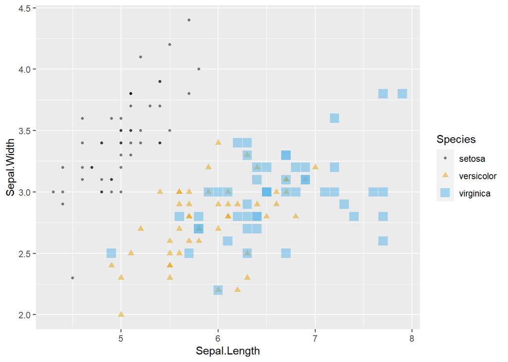

```r
iris %>%
  ggplot(mapping = aes(x = Sepal.Length, y = Sepal.Width)) +
  geom_point(mapping = aes(color = Species,
                           shape = Species,
                           size = Species),
             alpha = 0.5) +
  scale_size_manual(values = my_size_values) +
  ggthemes::scale_color_colorblind()
```

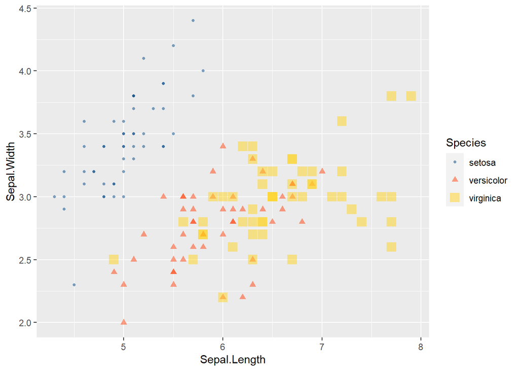

```r
iris %>%
  ggplot(mapping = aes(x = Sepal.Length, y = Sepal.Width)) +
  geom_point(mapping = aes(color = Species,
                           shape = Species,
                           size = Species),
             alpha = 0.5) +
  scale_size_manual(values = my_size_values) +
  ggthemes::scale_color_calc()
```

If you’re an Excel user.

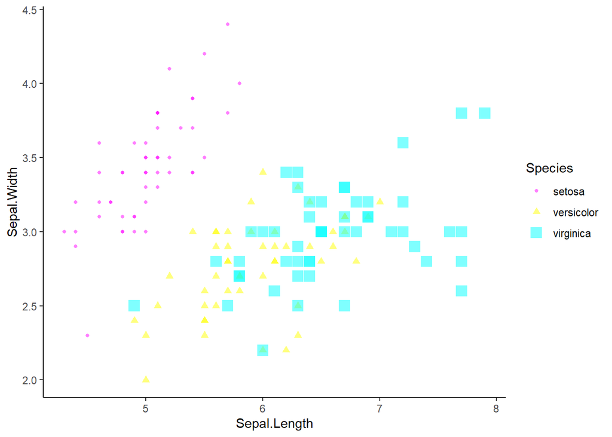

```r
iris %>%
  ggplot(mapping = aes(x = Sepal.Length, y = Sepal.Width)) +
  geom_point(mapping = aes(color = Species,
                           shape = Species,
                           size = Species),
             alpha = 0.5) +
  scale_size_manual(values = my_size_values) +
  ggthemes::scale_color_excel() +
  theme_classic()
```